# Fan In Fan Out Pilot Summary

Jonathan Nicholas and Daphna Shohamy

07/09/2018

- Design
- Pilot 1
- Pilot 2
- Pilot 3
- Pilot 4
- Pilot 5
- Stimulus Rating

### Initial Design

The task was programmed in PsychoPy following the specifications reported for sensory preconditioning in Wimmer & Shohamy, 2012. Neutrally rated face images were chosen from the Chicago Face Database and were matched to Columbia undergraduate demographics (race/gender). Scenes were chosen from Konkle, Brady, Alvarez, & Oliva, 2012 (Psych Science). Objects were chosen from Brady, Konkle, Alvarez, & Oliva, 2008 (PNAS).

[figure not shown]

The experiment consisted of the following procedure:

- **Image rating** (50 faces, 50 scenes, 50 objects) on a continuous "liking" scale. The most neutral images are then chosen to be presented in the task. Time: 10 minutes
- **Conditioning phase.** Trials: 160 total; 10/pair with 16 pairs. Time: 25 minutes
- **Reward learning phase.** Trials: 160 total; 20/pair with 8 pairs. Time: 30 minutes
- **Decision phase.** Trials: 96 total; 4/image combination. Time: 20 minutes
- **Memory and post-liking assessment.** Time: 5 minutes ###### Total Time: 90 minutes

#### Changes from Wimmer & Shohamy, 2012:

- Instead of detecting upside images during the conditioning phase, we opted to have participants indicate the category of the image in order to bring greater attention to the category distinction
- FIFO has two trial types (fan in; fan out). In order to have multiple A->C pairs/type, there are 16 pairs in total (2/category/type)
- There is no visual distinction between A and C images beyond the category (whereas in Wimmer & Shohamy the C images were all circular fractals)
- All phases are longer due to having multiple trial types

## Pilot 1: N=7 SONA participants

#### 02/07/18 - 02/13/18

The experiment was run in Testing Room A on a 2009 Mac Pro. 7 SONA participants were recruited for initial piloting. SONA participants were informed that they should try and maximize earned points since they would not be receiving monetary compensation.

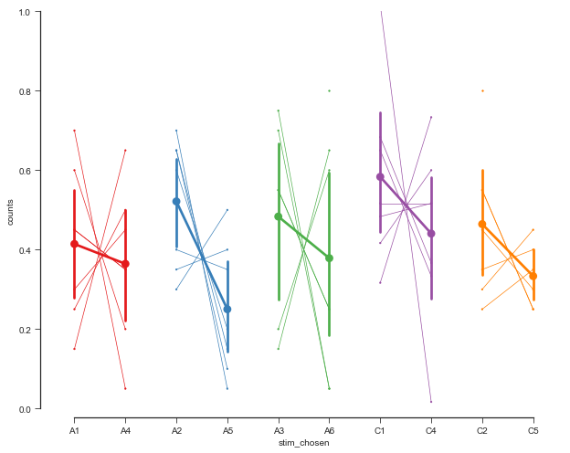

```python
pids = range(1,8)

mainData = pd.read_csv(os.path.join(expPath,"fullDataSONA1.csv"))

plotChoiceData(mainData=mainData,dSet="SONA1")
```

#### Results

Participants did not reliably learn the conditioned stimuli (C1 v C4; C2 v C5). Post-task questionnaires indicated that most were choosing based on criteria other than which they thought was most likely to lead to receiving a point. Thus, we changed the instructions to indicate that they should choose **only** based on this.

## Pilot 2: N=9 SONA participants

#### 02/14/18 - 02/28/18

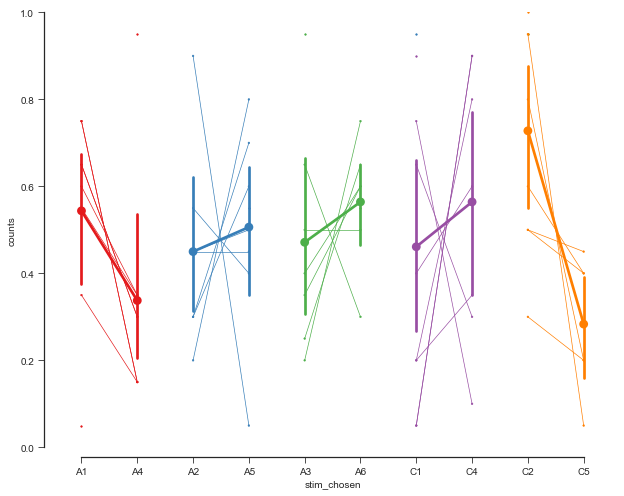

```python
pids = ["008","009","010","011","013","014","015","016","017"]

mainData = loadData(dType="main")

plotChoiceData(mainData=mainData)
```

#### Results

Several changes were made following this second SONA pilot:

- Paid participants were used instead of SONA participants
- The probability of receiving reward was changed from 80% to 100%
- Conditioning trials were increased from 20 to 25
- Rather than having participants rate images, we pre-selected "neutral" and discriminable images:
  - 8 neutral faces (matching Columbia demographics) were selected at random
  - 8 scenes that tended to be rated the most neutral by participants were selected
  - 8 neutrally rated and more discriminable objects were chosen from the Open Affective Standardized Image Set (OASIS)

## Pilot 3: N=16 paid participants

#### 03/01/18 - 05/15/18

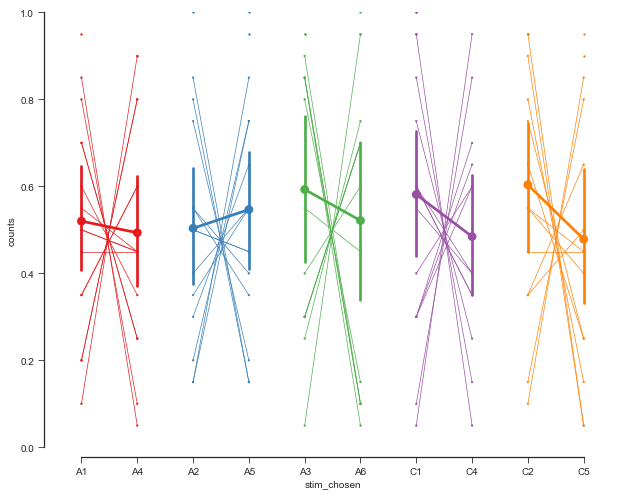

```python
pids = ["100","101","103","104","105","106","107","108","109","110","111","112","113","114","115","116"]

mainData = loadData(dType="main")

plotChoiceData(mainData=mainData)
```

## Pilot 4: N=7 paid participants

### Conditioning only

#### 05/15/18 - 06/01/18

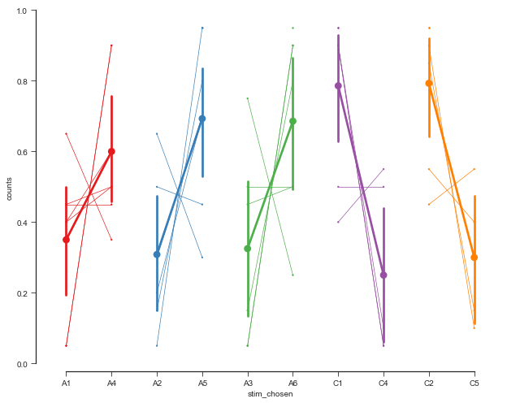

```python
pids = ["200","201","202","203","204","205","206"]

mainData = loadData(dType="main")

plotChoiceData(mainData=mainData)
```

#### Results

In addition, it was found that while running other processes, the computer in Testing Room A has unreliable stimulus presentation times. This resulted in, roughly, an average loss of .5 seconds per trial. Since there was more availability in other testing rooms, the experiment was moved to a different computer with confirmed reliable stimulus presentation timing.

# Pilot 5: N=18 paid participants

#### 06/01/18 - 08/01/18

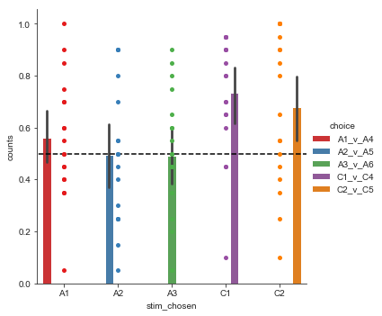

```python
pids = ["300","301","302","303","304","305",
        "306","307","308","309","310","318",
        "312","313","314","315","316","317"]

mainData = loadData(dType="main")

choiceData = plotChoiceData(mainData=mainData)
plt.show()
```

Participants appear to learn that conditioned stimuli at a rate beyond chance, although there is a stronger effect for faces (C1) than scenes (C2).

Participants do not learn the preconditioned stimuli at the group level, although there is a high degree of individual variation nearly split around the chance level. This is in line with previous studies using the sensory preconditioning from the lab.

### Hierarchical Linear Modeling

```python
modelData = getModelData()

import statsmodels.api as sm
import statsmodels.formula.api as smf

model = "counts ~ stim_chosen"
md = smf.mixedlm(model, modelData, groups=modelData["pid"])
mdf = md.fit()

print("MODEL FIT FOR %s"%(model))
print(mdf.summary())

modelData = modelData.dropna() # Remove the dummy-coded chance level rows

model = "counts ~ cond_type"
md = smf.mixedlm(model, modelData, groups=modelData["pid"])
mdf = md.fit()

print("\n")
print("MODEL FIT FOR %s"%(model))
print(mdf.summary())
```

```
MODEL FIT FOR counts ~ stim_chosen
            Mixed Linear Model Regression Results
============================================================
Model:               MixedLM   Dependent Variable:   counts
No. Observations:    108       Method:               REML
No. Groups:          18        Scale:                0.0518
Min. group size:     6         Likelihood:           -3.9212
Max. group size:     6         Converged:            No
Mean group size:     6.0
------------------------------------------------------------
                  Coef.  Std.Err.   z    P>|z| [0.025 0.975]
------------------------------------------------------------
Intercept          0.500    0.055  9.174 0.000  0.393  0.607
stim_chosen[T.A1]  0.061    0.076  0.806 0.420 -0.088  0.210
stim_chosen[T.A2] -0.006    0.076 -0.073 0.942 -0.154  0.143
stim_chosen[T.A3] -0.008    0.076 -0.110 0.913 -0.157  0.140
stim_chosen[T.C1]  0.236    0.076  3.113 0.002  0.087  0.385
stim_chosen[T.C2]  0.178    0.076  2.344 0.019  0.029  0.326
Group Var          0.002    0.013
============================================================



MODEL FIT FOR counts ~ cond_type
             Mixed Linear Model Regression Results
===============================================================
Model:                MixedLM    Dependent Variable:    counts
No. Observations:     90         Method:                REML
No. Groups:           18         Scale:                 0.0554
Min. group size:      5          Likelihood:            -6.1702
Max. group size:      5          Converged:             Yes
Mean group size:      5.0
---------------------------------------------------------------
                     Coef.  Std.Err.   z    P>|z| [0.025 0.975]
---------------------------------------------------------------
Intercept             0.707    0.045 15.768 0.000  0.619  0.795
cond_type[T.precond] -0.191    0.051 -3.776 0.000 -0.290 -0.092
Group Var             0.008    0.032
===============================================================
```

The first mixed model tests each choice type's difference from chance. The intercept is a variable called "random choice" that is set to 0.5 for each participant. We see here that both C1 (face) and C2 (scene) choices are different from 0.5 at the 95% confidence level.

The second mixed model tests whether there are differences between conditioned and preconditioned stimuli (collapsing across trial types). We see a strong effect where preconditioned stimuli are around 19% less likely to be chosen than conditioned stimuli.

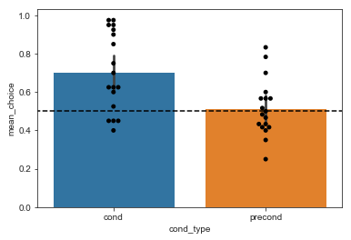

```python
aggChoiceData = modelData.groupby(["pid","cond_type"]).mean().counts.reset_index(name="mean_choice")
sns.barplot(x="cond_type",y="mean_choice",data=aggChoiceData)
sns.swarmplot(x="cond_type",y="mean_choice",data=aggChoiceData,color='k')
plt.plot((-1,2),(0.5,0.5),'k--')
plt.show()
```

Here we see the effect of conditionining type, collapsing across categories, as indicated by the second mixed model

### Median Split Analysis

Due to the large individual difference in response to the preconditioned stimuli, we can perform a median split to group individuals by performance on the preconditioning phase. Categories were collapsed into conditioning and preconditioning decisions (as in the second model above).

```python
choiceData = perform_median_split()
```

```
Preconditioning median performance is 0.4916666666666667
N participants in low group: 9
N participants in high group: 9
```

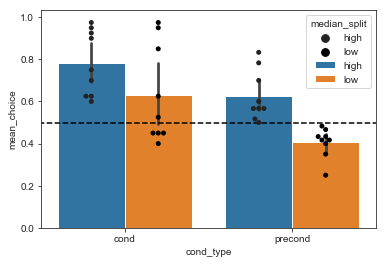

```python
pltData = choiceData[choiceData.stim_chosen.isin(["A1","A2","A3","C1","C2"])].reset_index()
aggPltData = pltData.groupby(["pid","median_split","cond_type"]).mean().counts.reset_index(name="mean_choice")
sns.barplot(x="cond_type",y="mean_choice",hue='median_split',data=aggPltData)
sns.swarmplot(x="cond_type",y="mean_choice",hue='median_split',data=aggPltData,dodge=True,color='k')
plt.plot((-1,2),(0.5,0.5),'k--')
plt.show()
```

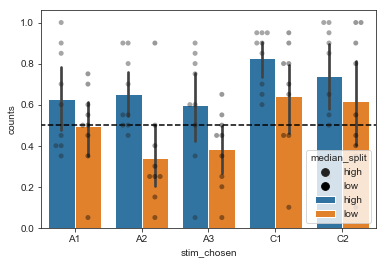

```python
pltData = choiceData[choiceData.stim_chosen.isin(["A1","A2","A3","C1","C2"])].reset_index()
sns.barplot(x="stim_chosen",y="counts",hue='median_split',data=pltData)
sns.swarmplot(x="stim_chosen",y="counts",hue='median_split',
              data=pltData,dodge=True,color='k',alpha=0.4)
plt.plot((-1,6),(0.5,0.5),'k--')
plt.show()
```

Plotting the proportion of choices broken down by choice type collapsed across category (plot 1), we see that, unsurprisingly, participants in the high group choose preconditioned stimuli more than participants in the low group (95% CI).

When we break this down by category (plot 2) we see overlapping confidence intervals for all but the A2 (scene) preconditioning choices

### Hierarchical Linear Modeling

To verify the second plot, where it looks like only the scene category preconditioning choice differs between groups, let's re-run the category-based model from before with a median-split group interaction term.

```python
import statsmodels.api as sm
import statsmodels.formula.api as smf

modelData = getModelData()

model = "counts ~ median_split*stim_chosen"
md = smf.mixedlm(model, modelData, groups=modelData["pid"])
mdf = md.fit()

print("MODEL FIT FOR %s"%(model))
print(mdf.summary())
```

```
MODEL FIT FOR counts ~ median_split*stim_chosen
                      Mixed Linear Model Regression Results
================================================================================
Model:                     MixedLM          Dependent Variable:          counts
No. Observations:          108              Method:                      REML
No. Groups:                18               Scale:                       0.0475
Min. group size:           6                Likelihood:                  -3.1793
Max. group size:           6                Converged:                   Yes
Mean group size:           6.0
--------------------------------------------------------------------------------
                                      Coef.  Std.Err.   z    P>|z| [0.025 0.975]
--------------------------------------------------------------------------------
Intercept                              0.500    0.073  6.880 0.000  0.358  0.642
median_split[T.low]                   -0.000    0.103 -0.000 1.000 -0.201  0.201
stim_chosen[T.A1]                      0.128    0.103  1.243 0.214 -0.074  0.329
stim_chosen[T.A2]                      0.150    0.103  1.459 0.144 -0.051  0.351
stim_chosen[T.A3]                      0.100    0.103  0.973 0.331 -0.101  0.301
stim_chosen[T.C1]                      0.328    0.103  3.189 0.001  0.126  0.529
stim_chosen[T.C2]                      0.239    0.103  2.324 0.020  0.037  0.440
median_split[T.low]:stim_chosen[T.A1] -0.133    0.145 -0.917 0.359 -0.418  0.152
median_split[T.low]:stim_chosen[T.A2] -0.311    0.145 -2.140 0.032 -0.596 -0.026
median_split[T.low]:stim_chosen[T.A3] -0.217    0.145 -1.491 0.136 -0.502  0.068
median_split[T.low]:stim_chosen[T.C1] -0.183    0.145 -1.261 0.207 -0.468  0.102
median_split[T.low]:stim_chosen[T.C2] -0.122    0.145 -0.841 0.400 -0.407  0.163
Group Var                              0.000    0.016
================================================================================
```

# Simple conditioning performed on mturk for 24 stimuli/category

#### 8/01/18 - 8/10/18

```python
exclude_blur = 50
interaction_data, exclude_pids = loadMTurkData(dType="interaction")
```

```python
data = loadMTurkData(dType="experiment")[0]
phase1_data = data[(data.trial_index < 650) & (data.test_part == "train")]
phase2_data = data[(data.trial_index > 650) & (data.test_part == "train")]
correctChoices = get_conditioned_choices()
faceChoices = correctChoices[correctChoices.category == 'face']
objectChoices = correctChoices[correctChoices.category == 'object']
sceneChoices = correctChoices[correctChoices.category == 'scene']
print("N = %s"%(len(data.subjectID.unique())))
```

```
N = 90
```

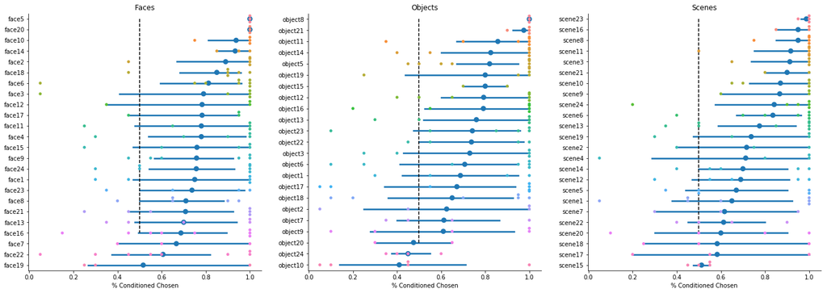

```python
f,ax = plt.subplots(1,3,figsize=(24,8))
sns.pointplot(y='imgChosen',x='prop_chosen',join=False,data=faceChoices,ax=ax[0])
sns.swarmplot(y='imgChosen',x='prop_chosen',data=faceChoices,ax=ax[0])
sns.pointplot(y='imgChosen',x='prop_chosen',join=False,data=objectChoices,ax=ax[1])
sns.swarmplot(y='imgChosen',x='prop_chosen',data=objectChoices,ax=ax[1])
sns.pointplot(y='imgChosen',x='prop_chosen',join=False,data=sceneChoices,ax=ax[2])
sns.swarmplot(y='imgChosen',x='prop_chosen',data=sceneChoices,ax=ax[2])
titles = ['Faces','Objects','Scenes']
for i_a, a in enumerate(ax):
    a.plot((0.5,0.5),(0,20),'k--')
    a.set_title(titles[i_a])
    a.set_ylabel("")
    a.set_xlabel("% Conditioned Chosen")
sns.despine(); plt.show()
plt.show()
```

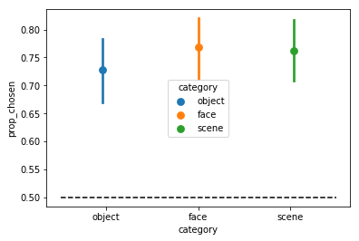

```python
g = sns.pointplot(x="category",y="prop_chosen",hue="category",data=correctChoices,join=False,dodge=True)
plt.plot((-0.5,2.5),(0.5,0.5),'k--'); plt.show()
```

###### All functions used to generate the above plots are below

```python
# Importing packages
%matplotlib inline
from __future__ import division
import warnings, os
warnings.filterwarnings('ignore')
import numpy as np
import pandas as pd
import matplotlib.pyplot as plt
import seaborn as sns

global expPath
global pids

expPath = "/Users/jonathan/shohamylab/fwdbwd/"

def loadData(dType=None,dataDir="data",fileType="stateData"):
    '''

    Load individual participant data into aggregated dataframe

    '''

    data = []
    for pid in pids:
        pidPath = os.path.join(expPath,dataDir,pid)
        dataFile = [d for d in os.listdir(pidPath) if dType in d and fileType in d][0]
        subData = pd.read_csv(os.path.join(pidPath,dataFile))
        subData["pid"] = [pid] * len(subData)
        data.append(subData)
    data = pd.concat(data,ignore_index=True)

    return data


def plotChoiceData(mainData=None,dSet=None,figsize=(10, 8)):
    '''

    Plot participant performance during the decision phase

    '''

    categoryIDs = mainData.groupby(["pid","stimulus1","category1"]).size().reset_index(name="counts")

    choiceData = mainData[mainData.stateName == "choice_phase3"]

    def chosen(row):
        if row["stimulus_position1"] == "(-0.5, 0)":
            if row["key_pressed"] == 1:
                return row["category1"]
            else:
                return row["category2"]
        elif row["stimulus_position1"] == "(0.5, 0)":
            if row["key_pressed"] == 2:
                return row["category1"]
            else:
                return row["category2"]

    choiceData['stim_chosen'] = choiceData.apply(chosen, axis=1)

    # Clean the data
    choiceData = choiceData[pd.notnull(choiceData.key_pressed)]

    plotChoiceDf = choiceData.groupby(["pid","category1","category2","stim_chosen"]).size() \
    .reset_index(name='counts')

    plotChoiceDf["choice"] = plotChoiceDf["category1"]+"_v_"+plotChoiceDf["category2"]

    plotChoiceDf.counts = plotChoiceDf.counts.astype(float)
    for i_row, row in plotChoiceDf.iterrows():

        if row.choice == "C1_v_C4" and dSet == "SONA1":
            numShown = 60
        else:
            numShown = 20

        plotChoiceDf.at[i_row,"counts"] = row.counts/numShown

    sns.set_style("ticks")

#     plt.figure(figsize=figsize)

#     for pid in pids:
#         pid_data = plotChoiceDf[plotChoiceDf.pid == pid]

#         params = dict(x="stim_chosen",y="counts",hue="choice",
#                       data=pid_data,scale=0.25,palette="Set1",
#                       order=["A1","A4","A2","A5","A3","A6","C1","C4","C2","C5"])

#         ax = sns.pointplot(**params)
#         ax.legend_.remove()

#     # plot the mean
#     params = dict(x="stim_chosen",y="counts",hue="choice",
#                   scale=1,palette="Set1",
#                   data=plotChoiceDf,
#                   order=["A1","A4","A2","A5","A3","A6","C1","C4","C2","C5"])

#     ax = sns.pointplot(**params)
#     ax.legend_.remove()
#     ax.set_ylim([0,1])
#     sns.despine(offset=10, trim=True);

    plot_options = ["A1","A2","A3","C1","C2"]

    # plot the mean
    params = dict(x="stim_chosen",y="counts",hue="choice",palette="Set1",
                  data=plotChoiceDf,order=plot_options)

    ax = sns.catplot(kind="bar",**params)
    # ax = sns.pointplot(**params)
    # ax.legend_.remove()
    # ax.set_ylim([0,1])
    #sns.despine(offset=10, trim=True);

    for pid in pids:
        pid_data = plotChoiceDf[plotChoiceDf.pid == pid]


        pid_data = pid_data[pid_data.stim_chosen.isin(plot_options)]

        params = dict(x="stim_chosen",y="counts",hue="choice",
                      data=pid_data,palette="Set1",
                      order=plot_options) #scale=0.25

        ax = sns.swarmplot(**params)
        ax.legend_.remove()

    plt.plot((-1,6),(0.5,0.5),'k--')

    return plotChoiceDf

def getModelData():

    cond_type = []
    for i_row, row in choiceData.iterrows():
        if row.stim_chosen in ["A1","A2","A3","A4","A5","A6"]:
            cond_type.append("precond")
        elif row.stim_chosen in ["C1","C2","C4","C5"]:
            cond_type.append("cond")
    choiceData['cond_type'] = cond_type

    modelData = choiceData[choiceData.stim_chosen.isin(["A1","A2","A3","C1","C2"])].reset_index()

    columns = modelData.columns
    for pid in modelData.pid.unique():
        newRow = {}
        for col in columns:
            if col == 'pid':
                newRow[col] = pid
            elif col == 'stim_chosen':
                newRow[col] = 'A0RandomChoice'
            elif col == 'counts':
                newRow[col] = 0.5
            elif col == 'median_split':
                newRow[col] = choiceData[choiceData.pid == pid].median_split.iloc[0]
            else:
                newRow[col] = np.nan
        modelData = modelData.append(newRow,ignore_index=True)

    return modelData

def perform_median_split():

    median_precond = aggChoiceData[aggChoiceData["cond_type"] == "precond"].mean_choice.median()
    print("Preconditioning median performance is %s"%(median_precond))

    median_split = {'pid':[],'group':[]}
    for pid in aggChoiceData.pid.unique():
        precond_choice = aggChoiceData[(aggChoiceData.pid == pid) & \
                                       (aggChoiceData.cond_type == 'precond')] \
                                       .mean_choice.iloc[0]
        if precond_choice > median_precond:
            median_split['group'].append('high')
        else:
            median_split['group'].append('low')
        median_split['pid'].append(pid)
    median_split = pd.DataFrame.from_dict(median_split)

    group_assignments = []
    for pid in choiceData.pid.unique():
        group_assignment = median_split[median_split.pid == pid].group.iloc[0]
        group_assignments.append([group_assignment] * len(choiceData[choiceData.pid == pid]))
    group_assignments = [i for j in group_assignments for i in j]
    choiceData['median_split'] = group_assignments

    for g in ["low","high"]:
        n_pids = len(choiceData[choiceData['median_split'] == g].pid.unique())
        print("N participants in %s group: %s"%(g, n_pids))

    return choiceData

def loadMTurkData(dType=None,
             dataDir="/Users/jonathan/shohamylab/jspych-exps/from_server/conditioning/data",
             fileType="stateData"):
    data, exclude_pids = [], []
    dataFiles = [d for d in os.listdir(dataDir) if dType in d]
    for f in dataFiles:
        subData = pd.read_csv(os.path.join(dataDir,f))
        if dType == "interaction":
            if len(subData[subData.event == 'blur']) >= exclude_blur:
                exclude_pids.append(f.split('_')[0])
            subData['subjectID'] = [f.split('_')[0]] * len(subData)
        elif dType == "experiment":
            bonus = float(f.split('_')[2].replace('bonus',''))
            subData['bonus'] = [bonus] * len(subData)
        data.append(subData)
    data = pd.concat(data,ignore_index=True)
    return data, exclude_pids

def get_conditioned_choices():

    choiceData = phase2_data.groupby(["subjectID","imgChosen","typeChosen"]) \
                 .size().reset_index(name="times_chosen")
    correctChoices = choiceData[(choiceData.typeChosen == "C2") | (choiceData.typeChosen == "C1")]
    correctChoices['prop_chosen'] = correctChoices['times_chosen']/20
    correctChoices = correctChoices[~correctChoices.subjectID.isin(exclude_pids)]

    choiceCategories = []
    for i_row, row in correctChoices.iterrows():
        img = row.imgChosen
        category = ''.join([i for i in img if not i.isdigit()])
        choiceCategories.append(category)
    correctChoices['category'] = choiceCategories

    # Sort choices based on mean
    mean_choice = correctChoices.groupby(["imgChosen"]).prop_chosen.mean() \
                  .reset_index(name="mean_choice")
    sorter = list(mean_choice.sort_values('mean_choice',ascending=False).imgChosen)
    correctChoices['imgSorter'] = correctChoices['imgChosen']
    correctChoices.imgSorter = correctChoices.imgChosen.astype("category")
    correctChoices.imgSorter.cat.set_categories(sorter, inplace=True)
    correctChoices = correctChoices.sort_values(["imgSorter"])
    return correctChoices
```